# Analysis on YOCOIN Data

Abhisek Banerjee, Nirmohi Dave

October 31, 2018

## Introduction

The YOCOIN analysis project aims to analyze data of the Etherium coin YOCOIN and find out if we can deduce anything significant from the available data.

## What is Etherium?

“Ethereum is a decentralized platform that runs smart contracts: applications that run exactly as programmed without any possibility of downtime, censorship, fraud or third-party interference. These apps run on a custom built blockchain, an enormously powerful shared global infrastructure that can move value around and represent the ownership of property.” [Source : https://www.ethereum.org/]

## What is ERC20?

ERC20 is a significant standard for tokens on Etherium. This defines a common list of rules that enables developers to accurately predict how new tokens will function within the larger Ethereum system. [Source : https://www.investopedia.com/news/what-erc20-and-what-does-it-mean-ethereum/]

## YOCOIN TOKEN

YOCOIN was founded & launched on December 7th, 2015. It is an open-ledger, publicly exchanged, peer-to-peer crypto currency that is designed for the general public worldwide and will be utilized to pay for goods and services by many different industries across the globe, including but not limited to the direct sales industry. It uses the Etherium network for transaction and storage. [Sources: https://yocoinweb.wordpress.com/, https://steemit.com/yocoin/@tonypeacock/things-you-should-know-about-yocoin]

We have analysed transaction data of YOCOIN over specific period of time.YOCOINs can be made of multiple tokens and 10^16 tokens make a single YOCOIN. Also there were 310,000,000 YOCOINs available at the time of our analysis.

## Our goal

We tried to achieve couple of things during this project.

1> We have taken the sellers and buyers information out of the dataset and tried to plot their frequencies to find out what distribution they follow.

2> We have taken number of transactions for different dates between 07-21-2016 and 02-05-2018, and the corresponding highest token prices for each day and then tried to find out any correlation between highest stock price and number of transactions in a particular day. To do this we split our dataset into multiple layers(bins) and computed correlation value for each layers.

## Preprocessing

Before starting the analysis, we have done some preprosessing on the data and removed few outliers.

1> We removed all the transections which were dealing with coins more than the total available coins.These were spurious transactiions and we do not need to consider these for our analysis.

2> Then we removed very big transactions and very small transactions. These were extreme outliers and removing these values yielded better results.

## Packages Used

We used the following packages in our code.

1>‘fitdistrplus’: This has been used to plot sellers and buyers data in different distributions.

2>‘ggplot2’: This has been used to plot data along the different axes with different attributes.

3> ‘reshape’ : This has been used to join tables.

## Analysis

```
Number of rows in unprocessed data: 746397
```

Summary of the unprocessed data:

```
    Sellers            Buyers          TimeStamps
 Min.   : 309659   Min.   :  14514   Min.   :1.469e+09
 1st Qu.:9911594   1st Qu.:9913576   1st Qu.:1.478e+09
 Median :9911594   Median :9915742   Median :1.484e+09
 Mean   :9854046   Mean   :9816628   Mean   :1.484e+09
 3rd Qu.:9912282   3rd Qu.:9918141   3rd Qu.:1.489e+09
 Max.   :9927144   Max.   :9927159   Max.   :1.518e+09
  TokenAmounts
 Min.   :1.000e+00
 1st Qu.:5.250e+16
 Median :2.210e+17
 Mean   :1.396e+73
 3rd Qu.:8.730e+17
 Max.   :1.158e+77
```

```
Number of outlier rows: 90
```

Summary of the outliers:

```
    Sellers            Buyers          TimeStamps
 Min.   :9911653   Min.   :9911653   Min.   :1.472e+09
 1st Qu.:9917007   1st Qu.:9911653   1st Qu.:1.472e+09
 Median :9922951   Median :9911653   Median :1.472e+09
 Mean   :9921471   Mean   :9911697   Mean   :1.472e+09
 3rd Qu.:9922951   3rd Qu.:9911653   3rd Qu.:1.472e+09
 Max.   :9926770   Max.   :9915616   Max.   :1.472e+09
  TokenAmounts
 Min.   :1.158e+77
 1st Qu.:1.158e+77
 Median :1.158e+77
 Mean   :1.158e+77
 3rd Qu.:1.158e+77
 Max.   :1.158e+77
```

Below is the table of outlying buyers and the frequencies of transactions.

```
  outlying_buyers Freq
1         9911653   89
2         9915616    1
```

Below is the table of outlying sellers and the frequencies of transactions.

```
  outlying_sellers Freq
1          9911653    1
2          9917007   34
3          9922951   34
4          9926770   21
```

First we removed impossible transactions.

```
    Sellers            Buyers          TimeStamps
 Min.   : 309659   Min.   :  14514   Min.   :1.469e+09
 1st Qu.:9911594   1st Qu.:9913582   1st Qu.:1.478e+09
 Median :9911594   Median :9915743   Median :1.484e+09
 Mean   :9854038   Mean   :9816616   Mean   :1.484e+09
 3rd Qu.:9912282   3rd Qu.:9918141   3rd Qu.:1.489e+09
 Max.   :9927144   Max.   :9927159   Max.   :1.518e+09
  TokenAmounts
 Min.   :1.000e+00
 1st Qu.:5.250e+16
 Median :2.210e+17
 Mean   :7.134e+19
 3rd Qu.:8.720e+17
 Max.   :1.000e+24
```

We did one more round of pre-processing and removed 1 percentile of data from both the sides.

```
Number of rows in processed data: 716323
```

Summary of the processed data:

```
    Sellers            Buyers          TimeStamps
 Min.   : 309659   Min.   :  14514   Min.   :1.469e+09
 1st Qu.:9911594   1st Qu.:9913670   1st Qu.:1.478e+09
 Median :9911594   Median :9915788   Median :1.483e+09
 Mean   :9852930   Mean   :9815750   Mean   :1.483e+09
 3rd Qu.:9912282   3rd Qu.:9918216   3rd Qu.:1.489e+09
 Max.   :9927144   Max.   :9927159   Max.   :1.518e+09
  TokenAmounts
 Min.   :1.100e+15
 1st Qu.:6.000e+16
 Median :2.295e+17
 Mean   :9.189e+18
 3rd Qu.:8.630e+17
 Max.   :2.000e+21
```

Summary of seller frequencies:

```
    Min.  1st Qu.   Median     Mean  3rd Qu.     Max.
     1.0      1.0      2.0     89.2      4.0 497900.0
```

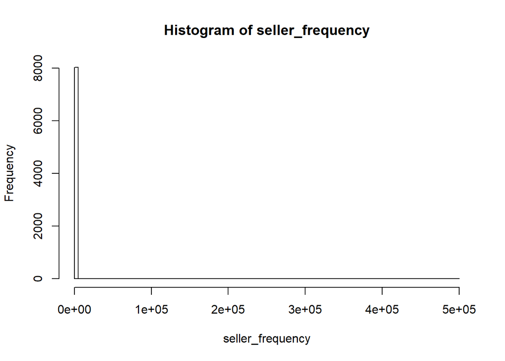

Summary of buyer frequencies:

```
   Min. 1st Qu.  Median    Mean 3rd Qu.    Max.
   1.00    2.00    8.00   46.18   25.00 7224.00
```

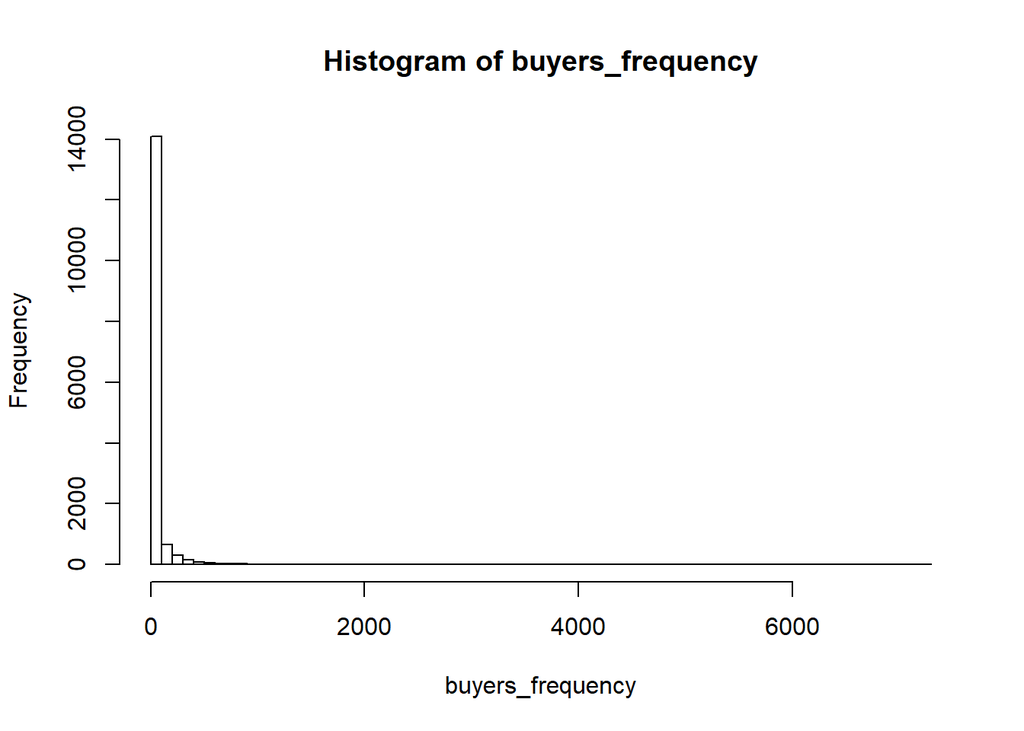

Summary of frequencies of sellers frequencies:

```
   Min. 1st Qu.  Median    Mean 3rd Qu.    Max.
   1.00    1.00    1.00   73.02    9.75 3586.00
```

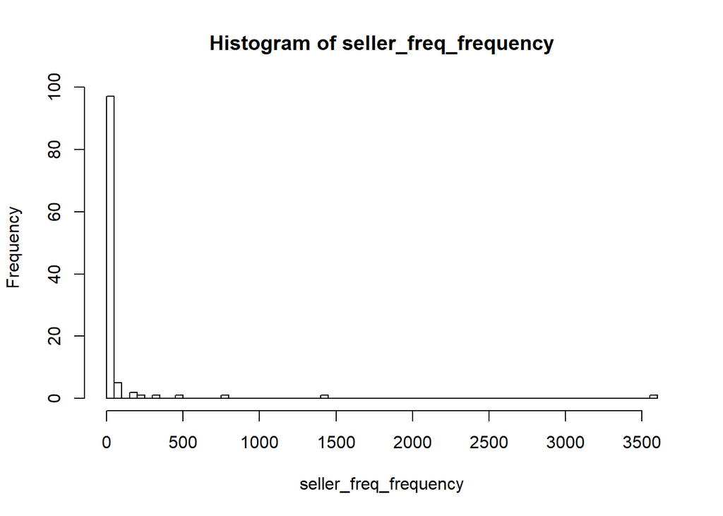

Summary of frequencies of buyers frequencies:

```
   Min. 1st Qu.  Median    Mean 3rd Qu.    Max.
   1.00    1.00    2.00   24.24    6.00 2621.00
```

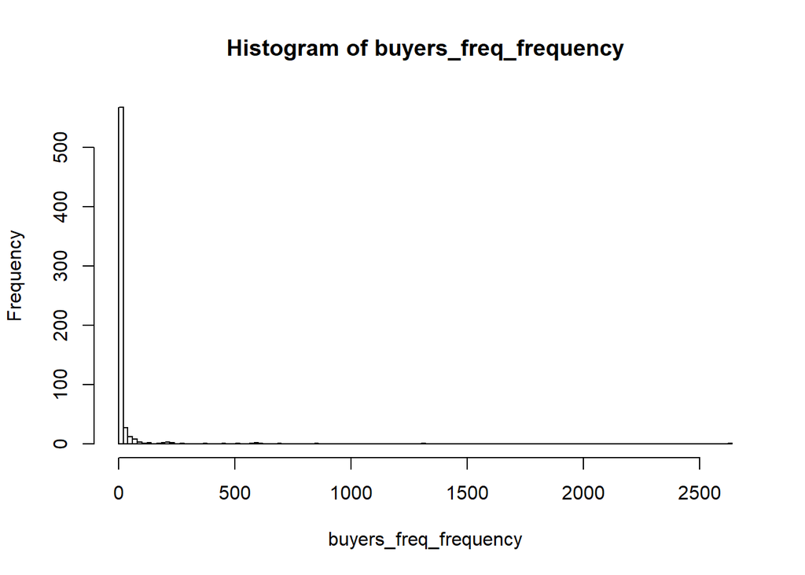

After analysing the data and plotting the histogram for the same, we made an assumption that the 4 distributions, namely, sellers frequencies, buyers frequencies, frequencies of sellers frequencies and frequencies of buyers frequencies follow exponential distributions.

## Analysis of the sellers and buyers data

We analysed the seller frequencies. Initially, we trimmed 1% of the data at the higher end to remove outliers.

Summary of data after trimming:

```
   Min. 1st Qu.  Median    Mean 3rd Qu.    Max.
  1.000   1.000   2.000   3.267   4.000  26.000
```

Plots for frequencies of sellers with exponential distribution:

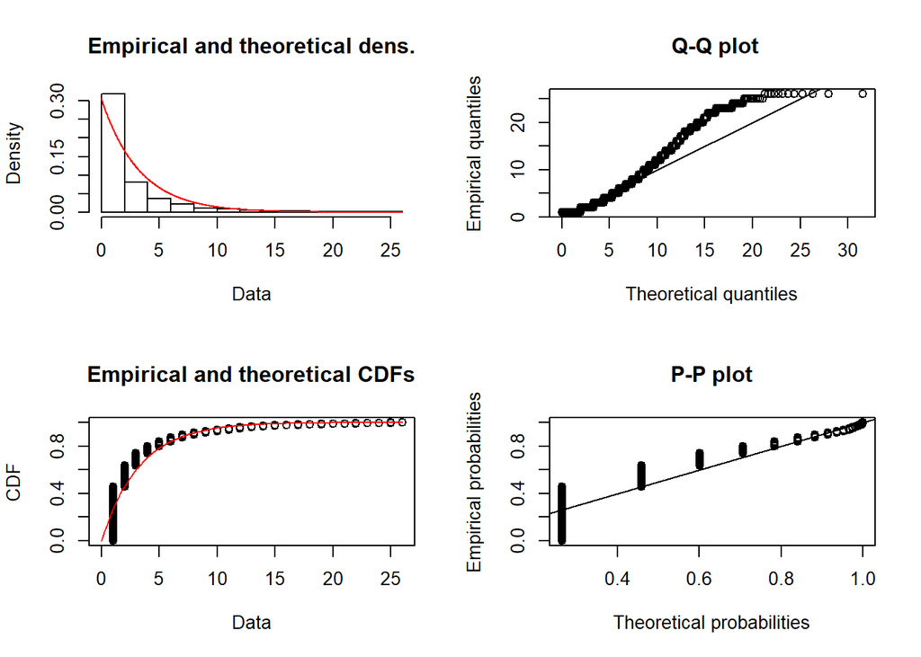

Now, we would draw the Cullen and Frey graph for this data set.

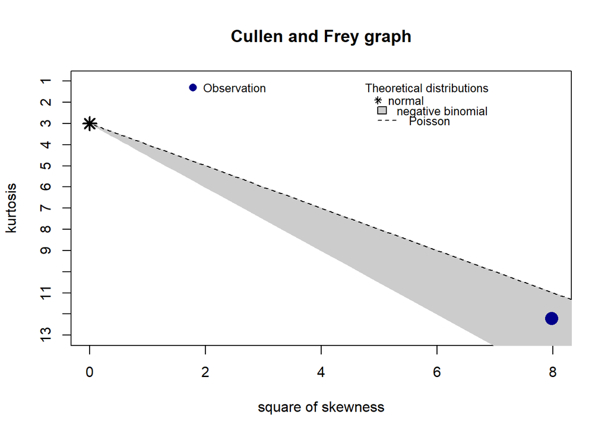

```
summary statistics
------
min:  1   max:  26
median:  2
mean:  3.266624
estimated sd:  3.918776
estimated skewness:  2.824363
estimated kurtosis:  12.20484
```

After drawing the Cullen and Frey graph, this looked somewhat close to negative binomial distribution. As our assumption was not in line with our findings with Cullen and Frey graph, we would consider our prior assumption as false and plot according to our findings.

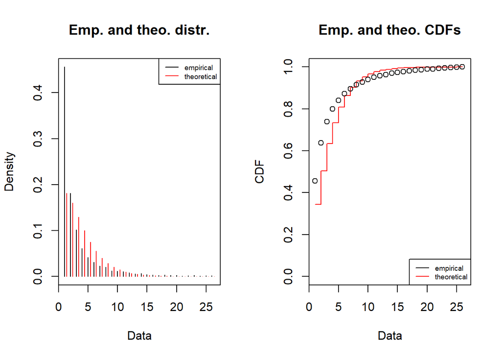

We analysed the buyers frequency. Initially, we trimmed 1% of the data at the higher end to remove outliers.

Summary of data after trimming:

```
   Min. 1st Qu.  Median    Mean 3rd Qu.    Max.
   1.00    2.00    8.00   33.07   24.00  662.00
```

Plots for frequencies of buyers with exponential distribution:

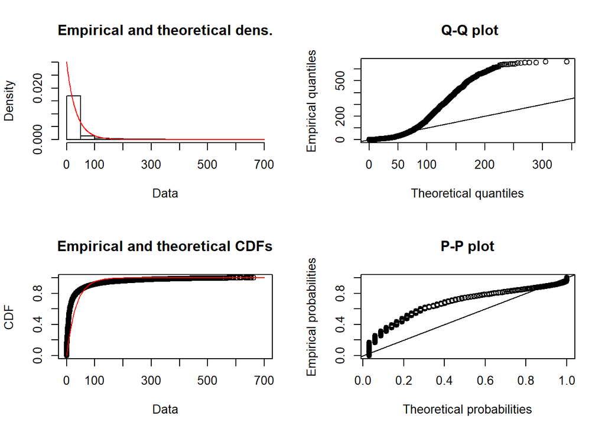

Now, we would draw the Cullen and Frey graph for this data set.

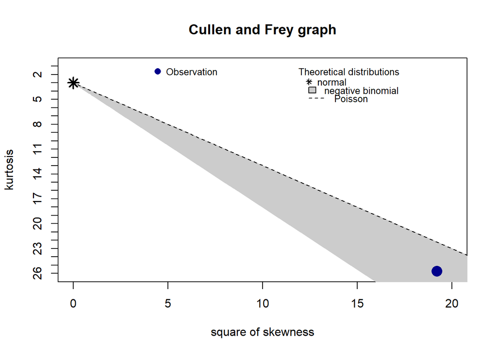

```
summary statistics
------
min:  1   max:  662
median:  8
mean:  33.07066
estimated sd:  74.64078
estimated skewness:  4.380931
estimated kurtosis:  25.71272
```

After drawing the Cullen and Frey graph, this looked somewhat close to negative binomial distribution. As our assumption was not in line with our findings with Cullen and Frey graph, we would consider our prior assumption as false and plot according to our findings.

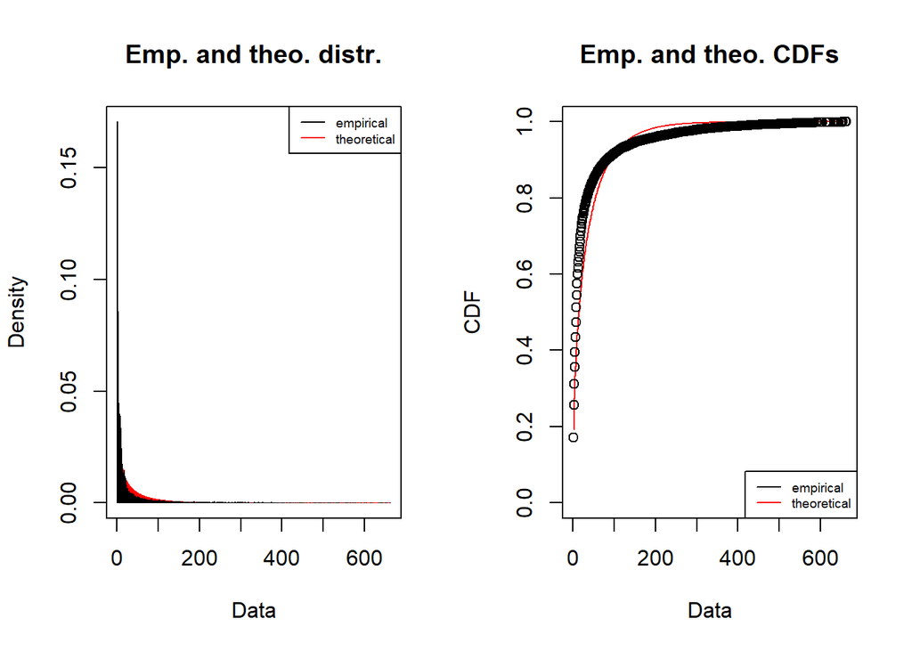

We analysed the frequencies of frequencies of sellers. Initially, we trimmed 1% of the data at the higher end to remove outliers.

Summary of data after trimming:

```
   Min. 1st Qu.  Median    Mean 3rd Qu.    Max.
   1.00    1.00    1.00   27.98    8.25  797.00
```

Plots for frequencies of frequencies of sellers with exponential distribution:

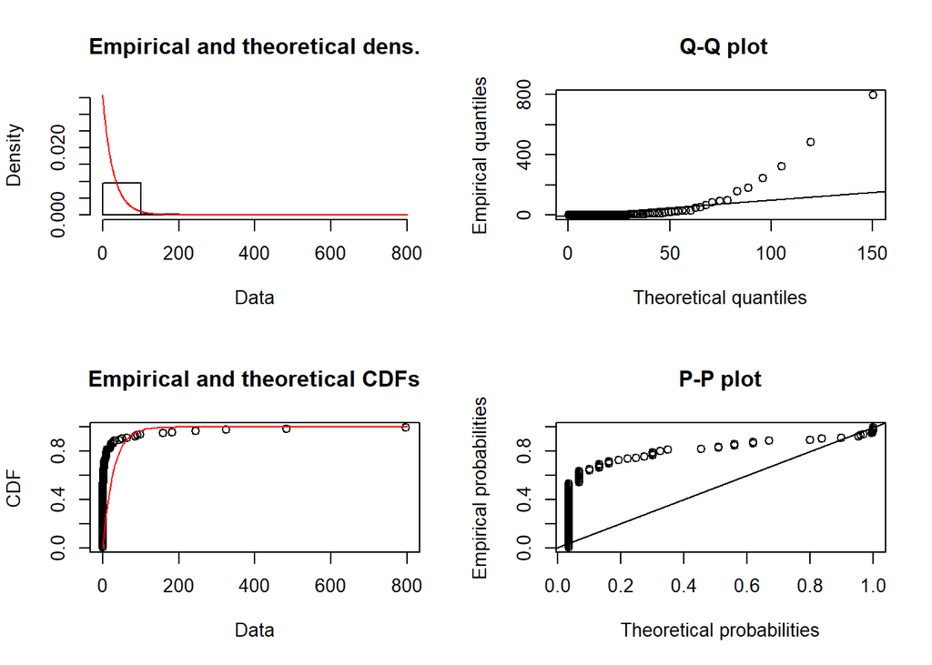

Now, we would draw the Cullen and Frey graph for this data set.

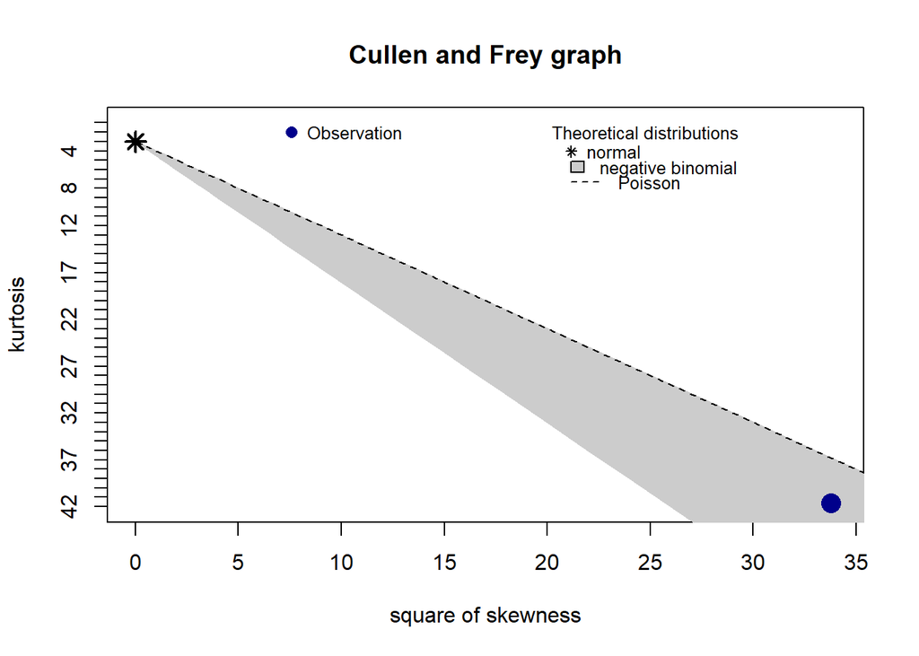

```
summary statistics
------
min:  1   max:  797
median:  1
mean:  27.98148
estimated sd:  98.89946
estimated skewness:  5.810142
estimated kurtosis:  41.59588
```

After drawing the Cullen and Frey graph, this looked somewhat close to negative binomial distribution. As our assumption was not in line with our findings with Cullen and Frey graph, we would consider our prior assumption as false and plot according to our findings.

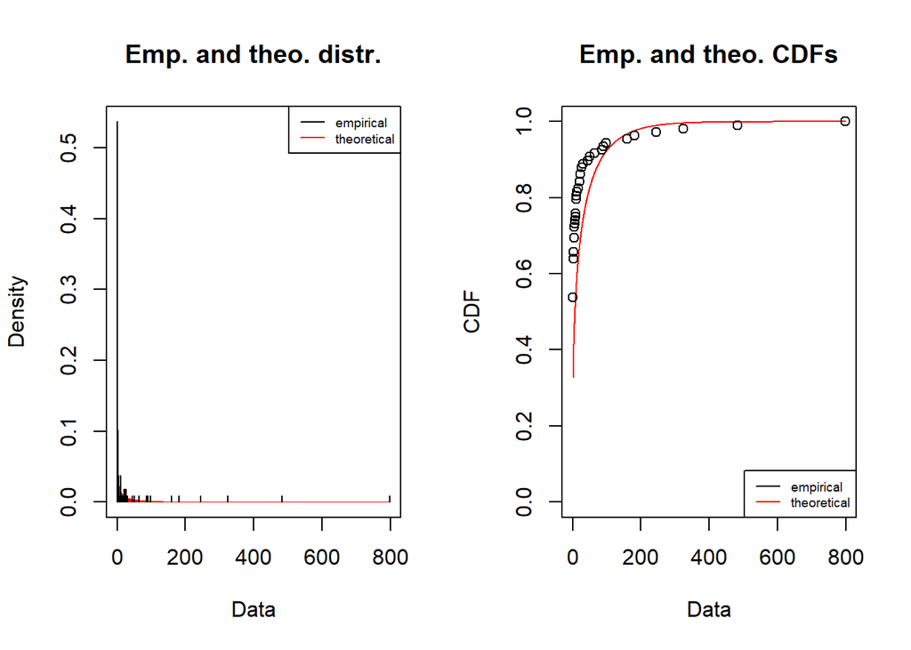

We analysed the frequencies of frequencies of buyers. Initially, we trimmed 1% of the data at the higher end to remove outliers.

Summary of data after trimming:

```
   Min. 1st Qu.  Median    Mean 3rd Qu.    Max.
   1.00    1.00    2.00   12.99    5.00  578.00
```

Plots for frequencies of frequencies of buyers with exponential distribution:

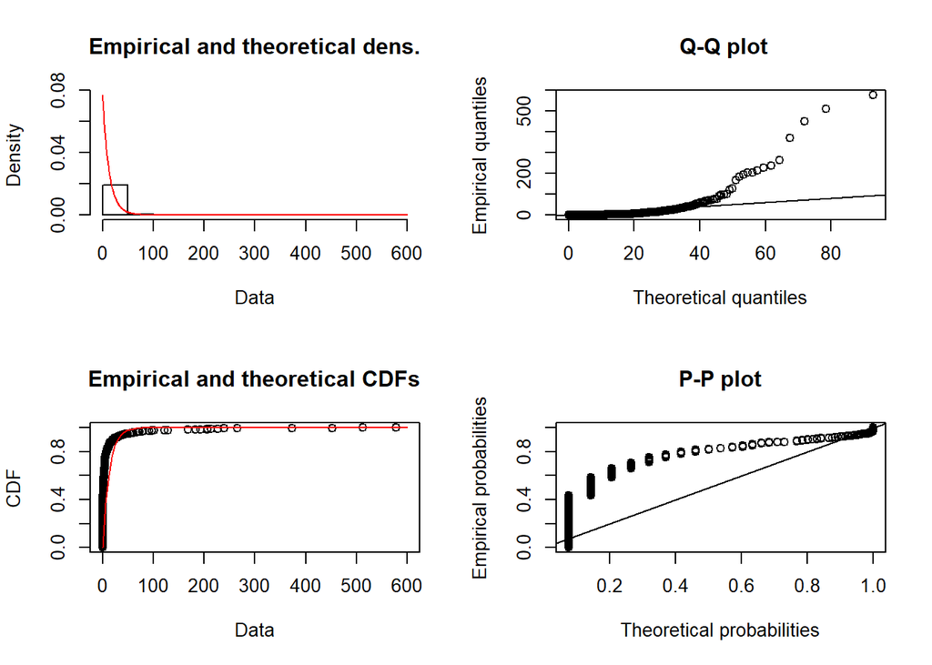

Now, we would draw the Cullen and Frey graph for this data set.

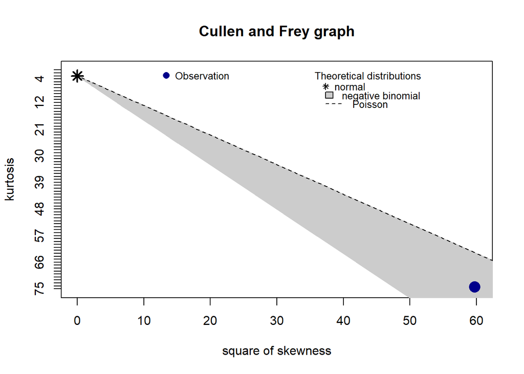

```
summary statistics
------
min:  1   max:  578
median:  2
mean:  12.99052
estimated sd:  47.37278
estimated skewness:  7.728049
estimated kurtosis:  74.34017
```

After drawing the Cullen and Frey graph, this looked somewhat close to negative binomial distribution. As our assumption was not in line with our findings with Cullen and Frey graph, we would consider our prior assumption as false and plot according to our findings.

[figure not shown]

We would create multiple layers from the data and merge them with the highest price for each day and check correlation between price and number of transactions using the Pearsons correlation formula.

## Layer 1

```
Minimum trx val= 1.9997e+20 Maximum trx val = 1.9997e+21
```

```
Number of rows in this layer :6439
```

```
Number of rows once this layer is removed :709884
```

```
    Pearson's product-moment correlation

data:  merged_table$High and merged_table$Freq
t = -1.6483, df = 402, p-value = 0.1001
alternative hypothesis: true correlation is not equal to 0
95 percent confidence interval:
 -0.1780746  0.0157570
sample estimates:
        cor
-0.08193354
```

Now we would plot number of transactions against transaction dates.

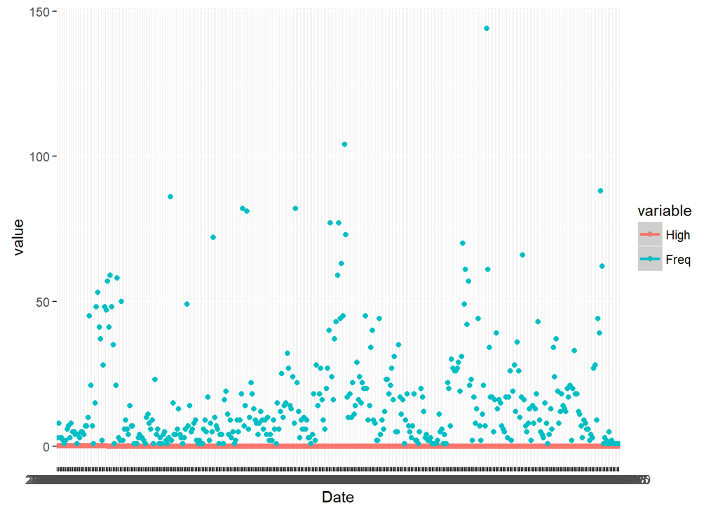

## Layer 2

```
Minimum trx val= 1.9997e+19 Maximum trx val = 1.9997e+21
```

```
Number of rows in this layer :20955
```

```
Number of rows once this layer is removed :688929
```

```
    Pearson's product-moment correlation

data:  merged_table$High and merged_table$Freq
t = -0.79756, df = 433, p-value = 0.4256
alternative hypothesis: true correlation is not equal to 0
95 percent confidence interval:
 -0.13184551  0.05592167
sample estimates:
        cor
-0.03829999
```

Now we would plot number of transactions against transaction dates.

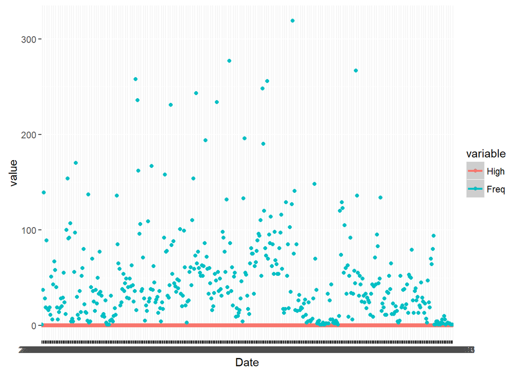

## Layer 3

```
Minimum trx val= 1.9997e+18 Maximum trx val = 1.9997e+21
```

```
Number of rows in this layer :87964
```

```
Number of rows once this layer is removed :600965
```

```
    Pearson's product-moment correlation

data:  merged_table$High and merged_table$Freq
t = 2.4889, df = 424, p-value = 0.0132
alternative hypothesis: true correlation is not equal to 0
95 percent confidence interval:
 0.02527627 0.21258302
sample estimates:
      cor
0.1199974
```

Now we would plot number of transactions against transaction dates.

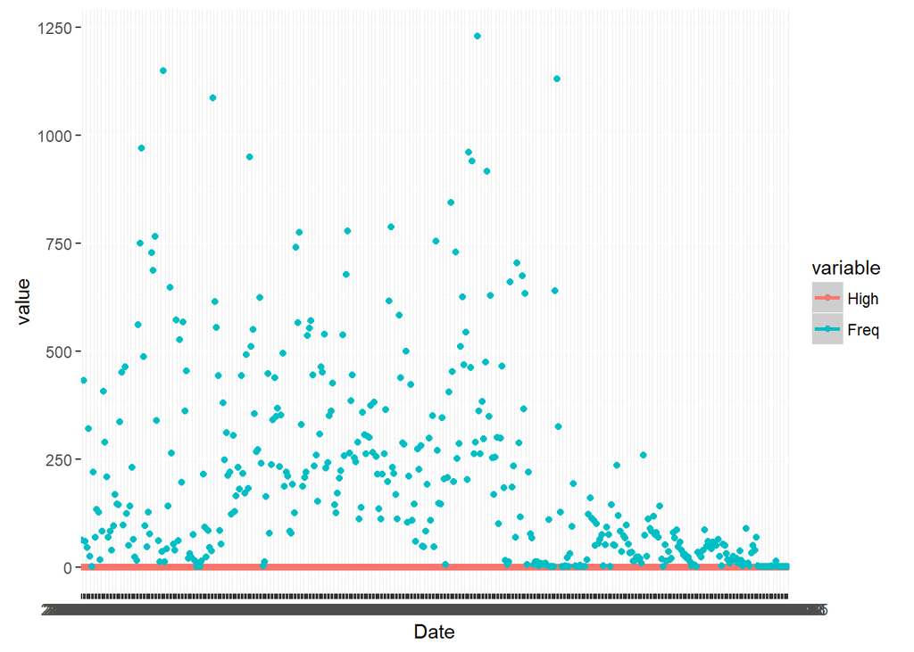

## Layer 4

```
Minimum trx val= 1.9997e+17 Maximum trx val = 1.9997e+21
```

```
Number of rows in this layer :269737
```

```
Number of rows once this layer is removed :331228
```

```
    Pearson's product-moment correlation

data:  merged_table$High and merged_table$Freq
t = 3.8332, df = 433, p-value = 0.0001452
alternative hypothesis: true correlation is not equal to 0
95 percent confidence interval:
 0.0886556 0.2705773
sample estimates:
      cor
0.1811658
```

Now we would plot number of transactions against transaction dates.

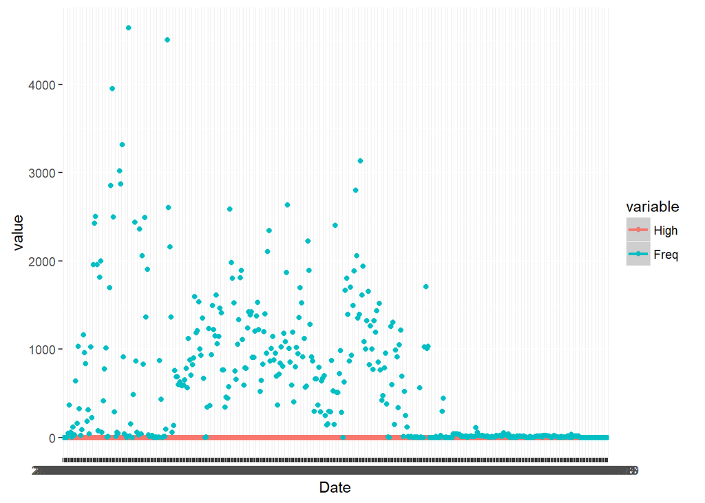

## Layer 5

```
Minimum trx val= 1.9997e+16 Maximum trx val = 1.9997e+21
```

```
Number of rows in this layer :239568
```

```
Number of rows once this layer is removed :91660
```

```
    Pearson's product-moment correlation

data:  merged_table$High and merged_table$Freq
t = 3.1492, df = 397, p-value = 0.001761
alternative hypothesis: true correlation is not equal to 0
95 percent confidence interval:
 0.0588448 0.2504535
sample estimates:
      cor
0.1561175
```

Now we would plot number of transactions against transaction dates.

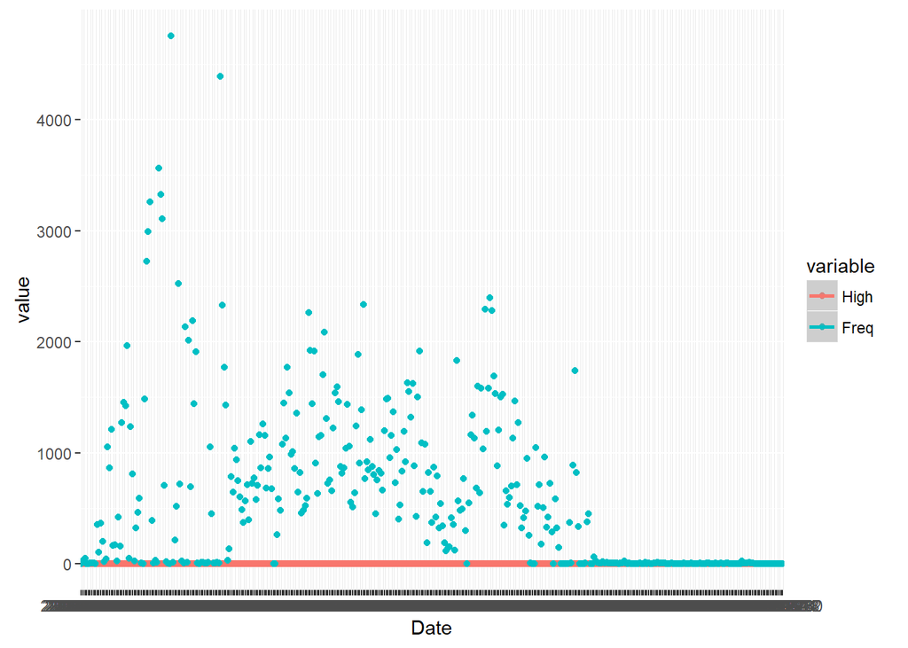

## Layer 6

```
Minimum trx val= 1.9997e+15 Maximum trx val = 1.9997e+21
```

```
Number of rows in this layer :89747
```

```
Number of rows once this layer is removed :1913
```

```
    Pearson's product-moment correlation

data:  merged_table$High and merged_table$Freq
t = -2.2307, df = 343, p-value = 0.02635
alternative hypothesis: true correlation is not equal to 0
95 percent confidence interval:
 -0.22236238 -0.01417363
sample estimates:
       cor
-0.1195823
```

Now we would plot number of transactions against transaction dates.

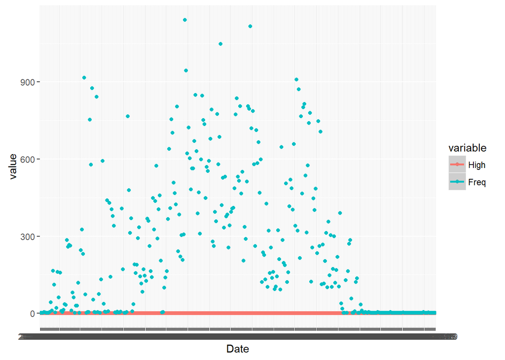

## Layer 7

```
Minimum trx val= 1.9997e+14 Maximum trx val = 1.9997e+21
```

```
Number of rows in this layer :1913
```

```
Number of rows once this layer is removed :0
```

```
    Pearson's product-moment correlation

data:  merged_table$High and merged_table$Freq
t = 0.1544, df = 196, p-value = 0.8775
alternative hypothesis: true correlation is not equal to 0
95 percent confidence interval:
 -0.1286116  0.1502381
sample estimates:
      cor
0.0110276
```

Now we would plot number of transactions against transaction dates.

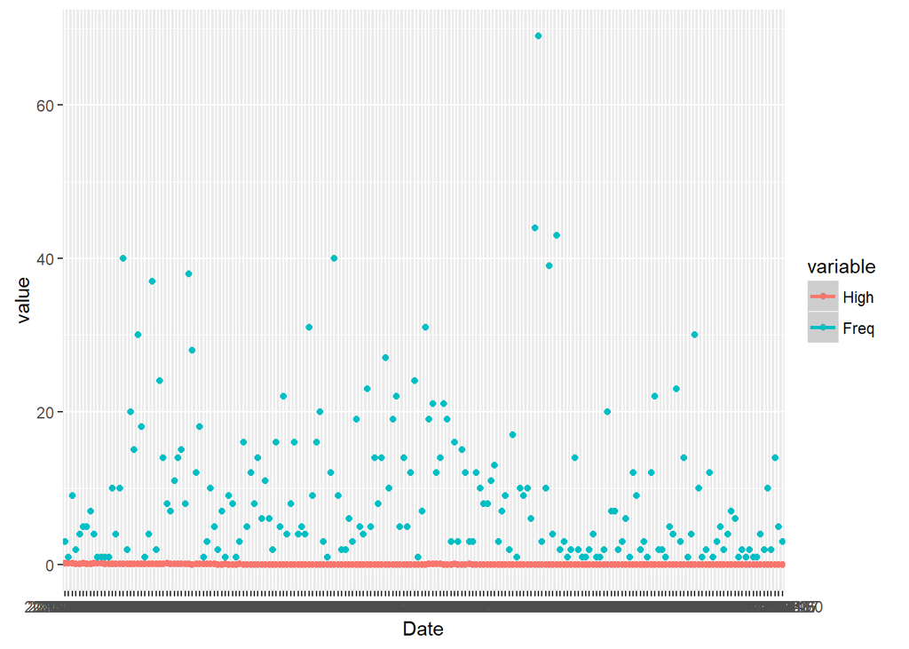

Correlation for the entire data set.

```
    Pearson's product-moment correlation

data:  merged_table$High and merged_table$Freq
t = 2.5619, df = 485, p-value = 0.01071
alternative hypothesis: true correlation is not equal to 0
95 percent confidence interval:
 0.02697443 0.20232875
sample estimates:
      cor
0.1155518
```

Now we would plot number of transactions against transaction dates.

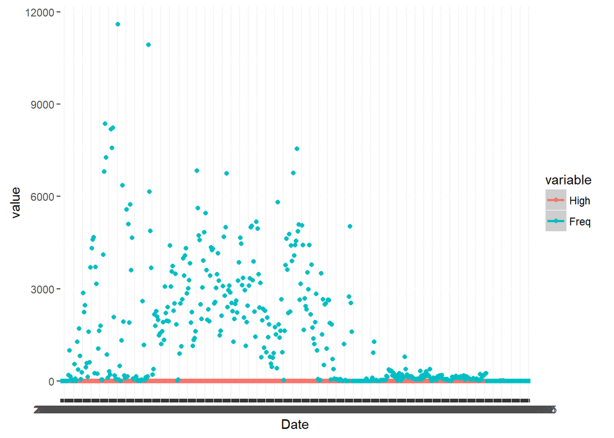

## Findings from different layers of data

The correlation values for different layers are very small with Layer 4 having the highest correlation value of 0.1811658 between number of transactions and the price of the coin.

## Conclusion

After analyzing the YOCOIN data we could not find much correlation between coin price and the number of transactions. So, we cannot draw any conclusion about the price of the coin on a particular day being dependent on the number of times coins were being bought or sold.